# Tan_Wei_Xuan_Final_Project

## A Study on the Key Factors Affecting the Purchasing Trend of HDB's Dwellings in Singapore

### Executive Summary:

The objective of this research is to analyze and identify the key factors affecting the purchasing Trend of HDB's Dwellings in Singapore. The relevant datasets and the required features have been identified and Date Cleaning, Web Scraping and Exploratory Data Analysis Techniques have been performed on these datasets to perform a comprehensive and accurate analysis of the defined research area. Factors such as the types of dwelling units, regions that the dwelling units are in, along with the remaining lease (years) and availability of amenities, were identified to have played an important role in determining the popularity of these dwelling units.

### Research Topic

*(A HDB Dwelling Unit refers to a HDB Residential Unit)*

The research topic that I have chosen will be the study on the key factors affecting Singapore's purchasing trend of HDB's Dwellings.The scope of my research will cover only sold HDB **Residential** Flats that ranges from 1-Room to Executive Flats **only**, **up to and inclusive of the year 2019**.

### Datasets:

*For Dataset 2, the data is created based on information extracted from Dataset 1's metadata*

1. `HDB Property Information (CSV)` - [Data.gov.sg - *Last Updated 5 July 2019*](https://data.gov.sg/dataset/hdb-property-information)
2. `Building Area Cluster Names (CSV)` - [*Adapted from metadata-hdb-property-information.txt*](https://drive.google.com/file/d/10EEm2E0dhgLa50i4SFsMMIdwicyZumfx/view?usp=sharing)
3. `Planning Areas of Singapore (Wikitable)` - [Wikipedia (Web Scraping) - *Last Updated 4 July 2019*](https://en.wikipedia.org/wiki/Planning_Areas_of_Singapore#List_of_Planning_Areas)

### Datasets Evaluation:

*Only the features of the datasets that are required/used for analysis are listed below.*

1. **`HDB Property Information`**describes **general statistics** on all the HDB Properties in Singapore according to the **location** of these Residential Units
- **blk_no:** *Block Number of the Residential Building*
- **street:** *Street Name of the Residential Building*
- **year_completed:** *Year Completed (Start of 99-Year Lease)*
- **residential:** *Residential Property Tag*
- **commercial:***Commercial Property Tag*
- **miscellaneous:** *Ameneties tag (Childcare, Committees Centre etc)*
- **bldg_contract_town:** *Building Area Cluster*
- **total_dwelling_units:** *Total Dwelling Units Sold*
- **1room_sold:** *Number of 1-room sold flats*
- **2room_sold:** *Number of 2-room sold flats*
- **3room_sold:** *Number of 3-room sold flats*
- **4room_sold:** *Number of 4-room sold flats*
- **5room_sold:** *Number of 5-room sold flats*
- **exec_sold:** *Number of Executives sold flats*

2. __`Building Area Cluster Names`__ describes the **Names** and **Location** of **Building Area Clusters** according to their **respective prefixes**

- **Legend:** *Prefix of the Building Area Cluster*
- **Name:** *Name of the Building Area Cluster*
- **Latitude** *Latitude of the Building Area Cluster*
- **Longitude:** *Longitude of the Building Area Cluster*

3. __`Planning Areas of Singapore`__ describes the statistics on the **Building Area Clusters**

- **Name:** *Name of the Building Area Cluster*
- **Region:** *Region of the Building Area Cluster*
- **Area:***Area (km<sup>2</sup>) of the Building Area Cluster*
- **Population:***Population within the Building Area Cluster*
- **Density:** *Density (km<sup>2</sup>) of the Building Area Cluster*

### Methodology

The inital step that was undertook prior to the commencement of any form of analysis on the datasets was to **clean the data by identifying and removing (or correcting) inaccurate records from these datasets**.

**Web Scraping Techniques were utilised to supplement more stastical information** to the datasets where necessary *(Supplementing HDB Property Information's Dataset with Planning Areas of Singapore's Dataset (Web Scraped)*

**Exploratory Data Analysis techniques** were utilised to **provide visual representations of the analytics done on the identified key focus areas**, generally through the use of (stacked) bar charts, historgrams, line graphs, etc. - depending the types of analysis that were required

**Geospatial Analysis Techniques *(Heat & Bubble Maps)* and Machine Learning *(Linear Regression)* Techniques** were implemented to provide a more in-depth analysis into the datasets

### Dependencies:

Ensure that these libraries are installed on your local machine.

1. [**`Pandas`**](https://pandas.pydata.org/pandas-docs/stable/install.html)
2. [**`NumPy`**](https://scipy.org/install.html)
3. [**`Plotly`**](https://plot.ly/python/getting-started/)
4. [**`Cufflinks`**](https://pypi.org/project/cufflinks/)
5. [**`Folium`**](https://python-visualization.github.io/folium/installing.html)
6. [**`Requests`**](https://2.python-requests.org/en/master/user/install/)
7. [**`BeautifulSoup`**](https://pypi.org/project/beautifulsoup4/)
8. [**`DateTime`**](https://pypi.org/project/DateTime/)
9. [**`Scikit-Learn`**](https://scikit-learn.org/stable/install.html)
10. [**`Matplotlib`**](https://matplotlib.org/3.1.1/faq/installing_faq.html)

### Import Libaries

```python
import pandas as pd
import numpy as np
import datetime
from sklearn import linear_model
from sklearn.model_selection import train_test_split
import folium as fol
from folium.plugins import HeatMap
import matplotlib.pyplot as plt
import plotly.plotly as py
from plotly.offline import iplot, init_notebook_mode
from plotly.offline import download_plotlyjs, init_notebook_mode, plot, iplot
import plotly.graph_objs as go
import plotly.figure_factory as ff
import cufflinks as cf
import requests
from bs4 import BeautifulSoup

init_notebook_mode(connected=True)

# Display all floats rounded off to 2 decimal place
pd.options.display.float_format = '{:,.8f}'.format
```

# Exploratory Data Analysis

### Cleaning of HDB Property's Dataset

We start off by reading the HDB Property Information.csv into a dataframe.

```python
#Read the HDP Property Information into dataframes
hdb_prop_info_unfilt_df = pd.read_csv("hdb-property-information.csv")

hdb_prop_info_unfilt_df.head()
```

|  | blk_no | street | max_floor_lvl | year_completed | residential | commercial | market_hawker | miscellaneous | multistorey_carpark | precinct_pavilion | ... | 3room_sold | 4room_sold | 5room_sold | exec_sold | multigen_sold | studio_apartment_sold | 1room_rental | 2room_rental | 3room_rental | other_room_rental |
| --- | --- | --- | --- | --- | --- | --- | --- | --- | --- | --- | --- | --- | --- | --- | --- | --- | --- | --- | --- | --- | --- |
| 0 | 1 | BEACH RD | 16 | 1970 | Y | Y | N | N | N | N | ... | 138 | 1 | 2 | 0 | 0 | 0 | 0 | 0 | 0 | 0 |
| 1 | 1 | BEDOK STH AVE 1 | 14 | 1975 | Y | N | N | Y | N | N | ... | 204 | 0 | 2 | 0 | 0 | 0 | 0 | 0 | 0 | 0 |
| 2 | 1 | CANTONMENT RD | 2 | 2010 | N | Y | N | N | N | N | ... | 0 | 0 | 0 | 0 | 0 | 0 | 0 | 0 | 0 | 0 |
| 3 | 1 | CHAI CHEE RD | 15 | 1982 | Y | N | N | N | N | N | ... | 0 | 10 | 92 | 0 | 0 | 0 | 0 | 0 | 0 | 0 |
| 4 | 1 | CHANGI VILLAGE RD | 4 | 1975 | Y | Y | N | N | N | N | ... | 54 | 0 | 1 | 0 | 0 | 0 | 0 | 0 | 0 | 0 |

5 rows × 24 columns

### Subtract away dwelling units that are not being used for analysis

We have to subtract out the number of dwelling units that are not being used for analysis the total number of dwelling units sold (Multi-gen/Studio units and Rented Units)

```python
filt_df = hdb_prop_info_unfilt_df.copy()

hdb_prop_info_unfilt_df['total_dwelling_units'] = filt_df ['total_dwelling_units'] - filt_df ['multigen_sold'] - filt_df['studio_apartment_sold'] - filt_df['1room_rental'] - filt_df['2room_rental'] - filt_df['3room_rental'] - filt_df['other_room_rental']
```

### Extracting Required Features Only

The dataframe consist of several columns that are **not required for analysis**. As not all of the features of the dataset are needed, we extract the **required features** only.

```python
#Extract the required features
hdb_prop_info_df =  hdb_prop_info_unfilt_df[['blk_no',
                                             'street',
                                             'year_completed',
                                             'residential',
                                             'commercial',
                                             'miscellaneous',
                                             'bldg_contract_town',
                                             'total_dwelling_units',
                                             '1room_sold',
                                             '2room_sold',
                                             '3room_sold',
                                             '4room_sold',
                                             '5room_sold',
                                             'exec_sold']]

#Checking for empty fields
null_columns = hdb_prop_info_df.columns[hdb_prop_info_df.isnull().any()]
print("There are", len(null_columns), "empty fields")

# There are 0 empty fields and thus we do not have to drop any NaN rows.

hdb_prop_info_df.head()
```

```
There are 0 empty fields
```

|  | blk_no | street | year_completed | residential | commercial | miscellaneous | bldg_contract_town | total_dwelling_units | 1room_sold | 2room_sold | 3room_sold | 4room_sold | 5room_sold | exec_sold |
| --- | --- | --- | --- | --- | --- | --- | --- | --- | --- | --- | --- | --- | --- | --- |
| 0 | 1 | BEACH RD | 1970 | Y | Y | N | KWN | 142 | 0 | 1 | 138 | 1 | 2 | 0 |
| 1 | 1 | BEDOK STH AVE 1 | 1975 | Y | N | Y | BD | 206 | 0 | 0 | 204 | 0 | 2 | 0 |
| 2 | 1 | CANTONMENT RD | 2010 | N | Y | N | CT | 0 | 0 | 0 | 0 | 0 | 0 | 0 |
| 3 | 1 | CHAI CHEE RD | 1982 | Y | N | N | BD | 102 | 0 | 0 | 0 | 10 | 92 | 0 |
| 4 | 1 | CHANGI VILLAGE RD | 1975 | Y | Y | N | PRC | 55 | 0 | 0 | 54 | 0 | 1 | 0 |

After extracting the required features, there are still several columns that needs to be cleaned. The columns are **residential**, **commercial**, **blk_no**,**street** and **bldg_contract_town**.

As we are doing an analysis for **Residential Units only**, we want to drop all the rows that are non-residential.

```python
hdb_prop_info_df = hdb_prop_info_df.drop(hdb_prop_info_df[hdb_prop_info_df.residential == 'N'].index)

hdb_prop_info_df.head()
```

|  | blk_no | street | year_completed | residential | commercial | miscellaneous | bldg_contract_town | total_dwelling_units | 1room_sold | 2room_sold | 3room_sold | 4room_sold | 5room_sold | exec_sold |
| --- | --- | --- | --- | --- | --- | --- | --- | --- | --- | --- | --- | --- | --- | --- |
| 0 | 1 | BEACH RD | 1970 | Y | Y | N | KWN | 142 | 0 | 1 | 138 | 1 | 2 | 0 |
| 1 | 1 | BEDOK STH AVE 1 | 1975 | Y | N | Y | BD | 206 | 0 | 0 | 204 | 0 | 2 | 0 |
| 3 | 1 | CHAI CHEE RD | 1982 | Y | N | N | BD | 102 | 0 | 0 | 0 | 10 | 92 | 0 |
| 4 | 1 | CHANGI VILLAGE RD | 1975 | Y | Y | N | PRC | 55 | 0 | 0 | 54 | 0 | 1 | 0 |
| 5 | 1 | DELTA AVE | 1982 | Y | N | N | BM | 96 | 0 | 0 | 0 | 0 | 96 | 0 |

The dataset will thus be left with buildings that are either fully residential *(By Tag: Residential = Y ,Commercial = N)* or are both Residential and Commercial *(By Tag: Residential = Y, Commercial = Y)*

We concatenate the **blk_no** column with the **street** column to make it easier to identify/understand the location of the respective HDB residential units. We create a new column **'Address'** to store the new values obtained.

```python
hdb_prop_info_df['Address'] = hdb_prop_info_df[['blk_no', 'street']].apply(lambda x: ' '.join(x), axis=1)

# We reorder the columns to put the ADDRESS column in front.
cols = list(hdb_prop_info_df.columns)
cols = [cols[-1]] + cols[:-1]
hdb_prop_info_df = hdb_prop_info_df[cols]

# With the Address Column, we can now drop the blk_no & street column
hdb_prop_info_df = hdb_prop_info_df.drop(columns=['blk_no', 'street'], axis=1)

hdb_prop_info_df.head()
```

|  | Address | year_completed | residential | commercial | miscellaneous | bldg_contract_town | total_dwelling_units | 1room_sold | 2room_sold | 3room_sold | 4room_sold | 5room_sold | exec_sold |
| --- | --- | --- | --- | --- | --- | --- | --- | --- | --- | --- | --- | --- | --- |
| 0 | 1 BEACH RD | 1970 | Y | Y | N | KWN | 142 | 0 | 1 | 138 | 1 | 2 | 0 |
| 1 | 1 BEDOK STH AVE 1 | 1975 | Y | N | Y | BD | 206 | 0 | 0 | 204 | 0 | 2 | 0 |
| 3 | 1 CHAI CHEE RD | 1982 | Y | N | N | BD | 102 | 0 | 0 | 0 | 10 | 92 | 0 |
| 4 | 1 CHANGI VILLAGE RD | 1975 | Y | Y | N | PRC | 55 | 0 | 0 | 54 | 0 | 1 | 0 |
| 5 | 1 DELTA AVE | 1982 | Y | N | N | BM | 96 | 0 | 0 | 0 | 0 | 96 | 0 |

The **bld_contract_town** column is a prefix correlating to the Name of the Building Area Cluster and to make it more comprehensible, we can replace the prefix with their relevant **Building Area Cluster names**

```python
#Import the Building Area Culster Names data to a dataframe
bld_area_cluster_names_df = pd.read_csv("Building Area Cluster Names.csv")
```

```python
#Create the function to match prefix -> name
def prefix_to_name(prefix):
    for index, row in bld_area_cluster_names_df.iterrows():
        if (prefix == row[0]):
            return row[1]
```

```python
#This will take some time to load as we are looping and replacing alot of values
hdb_prop_info_df['bldg_contract_town'] = hdb_prop_info_df['bldg_contract_town'].apply(prefix_to_name)

hdb_prop_info_df.head()
```

|  | Address | year_completed | residential | commercial | miscellaneous | bldg_contract_town | total_dwelling_units | 1room_sold | 2room_sold | 3room_sold | 4room_sold | 5room_sold | exec_sold |
| --- | --- | --- | --- | --- | --- | --- | --- | --- | --- | --- | --- | --- | --- |
| 0 | 1 BEACH RD | 1970 | Y | Y | N | KALLANG | 142 | 0 | 1 | 138 | 1 | 2 | 0 |
| 1 | 1 BEDOK STH AVE 1 | 1975 | Y | N | Y | BEDOK | 206 | 0 | 0 | 204 | 0 | 2 | 0 |
| 3 | 1 CHAI CHEE RD | 1982 | Y | N | N | BEDOK | 102 | 0 | 0 | 0 | 10 | 92 | 0 |
| 4 | 1 CHANGI VILLAGE RD | 1975 | Y | Y | N | PASIR RIS | 55 | 0 | 0 | 54 | 0 | 1 | 0 |
| 5 | 1 DELTA AVE | 1982 | Y | N | N | BUKIT MERAH | 96 | 0 | 0 | 0 | 0 | 96 | 0 |

## Dwelling Units Sold by Type based on Building Year Completion of Residential Areas (Remaining Lease)

> We will analyze the trend of the number dwelling units by type being based on the building year completion of the residential areas

We will first start off with analyzing the number of Residential Areas that is being completed for each year.

```python
red_area_by_year__gb = hdb_prop_info_df.groupby(['year_completed'], as_index=False).agg({"Address": "count"})

red_area_by_year__gb.head()
```

|  | year_completed | Address |
| --- | --- | --- |
| 0 | 1937 | 20 |
| 1 | 1938 | 2 |
| 2 | 1949 | 30 |
| 3 | 1955 | 2 |
| 4 | 1958 | 8 |

```python
trace0 = go.Scatter(
    x = red_area_by_year__gb['year_completed'],
    y = red_area_by_year__gb['Address'],
    mode = 'markers',
    marker=dict(
        size= red_area_by_year__gb['Address'],
        sizemode='area',
        sizeref=2.*max(red_area_by_year__gb['Address'])/(40.**2),
        sizemin=4,
        color = 'rgb(44, 160, 101)'
    )
)

data = [trace0]

layout = dict(title = 'Number of Residential Areas Completed by Year',
              yaxis = dict(zeroline = False, title = "Number of Residential Areas"),
              xaxis = dict(zeroline = False, title = "Year Completed")
             )

fig = dict(data=data, layout=layout)
iplot(fig, filename='bubblechart-size-ref')
```

[interactive chart not shown]

### ANALYSIS

Majority of the residential areas are completed **between the year 1978 to 1999** with the most number of residential units being completed in **1984**.

There was a brief period **between the year 2002 to 2010** where the number of residential units being completed are very little. This may be due to the low demand of housing during that period of time or that there wasn't enough land in Singapore for development purposes.

Next, we group the total number of units sold by type according the year that its residential area is being completed and calculate the remaining lease available of that residential area.

```python
now = datetime.datetime.now()

hdb_prop_year_gb = hdb_prop_info_df.groupby(['year_completed'], as_index=False).agg({"total_dwelling_units":"sum",
                                                                                     "1room_sold":"sum",
                                                                                    "2room_sold":"sum",
                                                                                    "3room_sold":"sum",
                                                                                    "4room_sold":"sum",
                                                                                    "5room_sold":"sum",
                                                                                    "exec_sold":"sum"})

hdb_prop_year_gb['remaining_lease'] = hdb_prop_year_gb['year_completed'].apply(lambda x: (x+99)- now.year)

hdb_prop_year_gb.head()
```

|  | year_completed | total_dwelling_units | 1room_sold | 2room_sold | 3room_sold | 4room_sold | 5room_sold | exec_sold | remaining_lease |
| --- | --- | --- | --- | --- | --- | --- | --- | --- | --- |
| 0 | 1937 | 753 | 0 | 52 | 270 | 427 | 4 | 0 | 17 |
| 1 | 1938 | 26 | 0 | 2 | 6 | 15 | 2 | 1 | 18 |
| 2 | 1949 | 559 | 0 | 30 | 509 | 20 | 0 | 0 | 29 |
| 3 | 1955 | 83 | 0 | 0 | 82 | 1 | 0 | 0 | 35 |
| 4 | 1958 | 0 | 0 | 0 | 0 | 0 | 0 | 0 | 38 |

Plot the **Line Graph** for the **amount of each dwelling unit types sold based on Building Year Completion of Residential Area**

```python
trace0 = go.Scatter(
                    x = hdb_prop_year_gb['remaining_lease'] ,
                    y = hdb_prop_year_gb['1room_sold'],
                    name = '1-Room Sold',
                    opacity = 0.5
                   )

trace1 = go.Scatter(
                    x = hdb_prop_year_gb['remaining_lease'] ,
                    y = hdb_prop_year_gb['2room_sold'],
                    name = '2-Room Sold',
                    opacity = 0.5
                  )

trace2 = go.Scatter(
                    x = hdb_prop_year_gb['remaining_lease'] ,
                    y = hdb_prop_year_gb['3room_sold'],
                    name = '3-Room Sold',
                    opacity = 0.5
                  )


trace3 = go.Scatter(
                    x = hdb_prop_year_gb['remaining_lease'] ,
                    y = hdb_prop_year_gb['4room_sold'],
                    name = '4-Room Sold',
                    opacity = 0.5
                  )


trace4 = go.Scatter(
                    x = hdb_prop_year_gb['remaining_lease'] ,
                    y = hdb_prop_year_gb['5room_sold'],
                    name = '5-Room Sold',
                    opacity = 0.5
                  )


trace5 = go.Scatter(
                    x = hdb_prop_year_gb['remaining_lease'] ,
                    y = hdb_prop_year_gb['exec_sold'],
                    name = 'Executive Sold',
                    opacity = 0.5
                  )


data = [trace0, trace1, trace2,trace3, trace4, trace5]


layout = dict(

        title = "Total Dwelling Units Sold by Type based on Remaining Lease (Years)",
        xaxis = dict(title ="Remaing Lease (Years)",automargin=True),
        yaxis = dict(title = "Total Dwelling Units Sold"),
        autosize=True
)


fig = dict(data=data, layout=layout)

iplot(fig)
```

[interactive chart not shown]

*(Click on the legend to isolate each trace)*

### ANALYSIS

When a Residential area is been completed, it denotes the starts of its 99-year lease.

From the graph above, dwelling units with a remaining lease of **64 years** tend to be the most popular purchases among Singaporeans.

However, each type of dwelling units have a different trend to how its remaining lease affects it's selling rate. *(We will be omitting the analysis of 1-Room Flat as there is too little data for analysis)*

For **2-Room Flats**, the peak of its sales is with flats with a remaining lease of **97 years**. It can thus be said that most of the 2-Room Flats newly developed as there were **almost zero sales** of 2-Room Flats with remaining leases of **61 to 89 years**.

For **3-Room Flats**, units with remaining lease of **58 and 64 years** have the most sales and there were almost zero sales of 3-Room Flats with remaining leases of 69 to 86 years. This could mean that there may be a low demand for 3-Room Flats during that period of time.

There are constantly a large number of **4-Room Flats** being sold regardless of the remaining leases the units. The trend of the sales 4-Room Flats is rather identifical to the trend of the number of residential units completed for each year. it can thus be said that **4-Room Flats** are constantly in high demand.

The peak of the sales of both **5-Room and Executive Flats** are with flats with a remaining lease of **72 to 79 years**. Compared to **3 and 4-Room Flats**, **5-Room and Executive Flats** became much more popular at a later date.

Based on these analysis, it can be concluded that how the remaining lease affect the sales rate differ rather significantly between the different types of dwelling units.

## Distribution of Dwelling Units Sold

> We will analyze the **distribution of dwelling units** for the entire dataset.

```python
print("The skewness of the distribution of the dwelling units is: ", hdb_prop_info_df['total_dwelling_units'].skew())

data = [
  go.Histogram(
    x = hdb_prop_info_df['total_dwelling_units'],
    name = "count",
    xbins=dict(
        start=0.0,
        end= 600,
        size=15
    ),
    marker=dict(
        color='#EB89B5'
    ),
    opacity=0.75
  )
]


layout = go.Layout(
        title = 'Distribution of Dwelling units Sold',
        xaxis = dict(title = 'Dwelling Units'),
        yaxis = dict(title = 'Frequency'),
        bargroupgap = 0.1,
        shapes=[dict({
            'type': 'line',
            'x0': hdb_prop_info_df['total_dwelling_units'].mean(),
            'y0': 0,
            'x1': hdb_prop_info_df['total_dwelling_units'].mean(),
            'y1': 1800,
            'line': {
                'color': '#8bbe1b',
                'width': 3,
                'dash' : 'dashdot'
            }}),
            dict({
            'type': 'line',
            'x0': hdb_prop_info_df['total_dwelling_units'].median(),
            'y0': 0,
            'x1': hdb_prop_info_df['total_dwelling_units'].median(),
            'y1': 1800,
            'line': {
                'color': '#e12c2c',
                'width': 3,
                'dash' : 'dashdot'
            }}),
            dict({
            'type': 'line',
            'x0': hdb_prop_info_df['total_dwelling_units'].mode()[0],
            'y0': 0,
            'x1': hdb_prop_info_df['total_dwelling_units'].mode()[0],
            'y1': 1800,
            'line': {
                'color': '#cc338b',
                'width': 3,
                'dash' : 'dashdot'
            }})],
        annotations=[
        dict(
            x=500,
            y=1800,
            xref='x',
            yref='y',
            text="Skewness: " +  str(hdb_prop_info_df['total_dwelling_units'].skew()),
            showarrow=False,
            ax=0,
            ay=-40
        ),
        dict(
            x=500,
            y=1700,
            xref='x',
            yref='y',
            text="Mean: " +  str(hdb_prop_info_df['total_dwelling_units'].mean()),
            showarrow=False,
            ax=0,
            ay=-40
        ),
        dict(
            x=500,
            y=1600,
            xref='x',
            yref='y',
            text="Median: " +  str(hdb_prop_info_df['total_dwelling_units'].median()),
            showarrow=False,
            ax=0,
            ay=-40
        ),
        dict(
            x=500,
            y=1500,
            xref='x',
            yref='y',
            text="Mode: " +  str(hdb_prop_info_df['total_dwelling_units'].mode()[0]),
            showarrow=False,
            ax=0,
            ay=-40
        ),
       dict(
            x=hdb_prop_info_df['total_dwelling_units'].mean(),
            y=1800,
            xref='x',
            yref='y',
            text='Mean',
            showarrow=True,
            arrowhead=1,
            ax=0,
            ay=-70,
            arrowwidth = 1
        ),
       dict(
            x=hdb_prop_info_df['total_dwelling_units'].median(),
            y=1800,
            xref='x',
            yref='y',
            text='Median',
            showarrow=True,
            arrowhead=1,
            ax=0,
            ay=-50,
            arrowwidth = 1
        ),
      dict(
            x=hdb_prop_info_df['total_dwelling_units'].mode()[0],
            y=1800,
            xref='x',
            yref='y',
            text='Mode',
            showarrow=True,
            arrowhead=1,
            ax= 0,
            ay=-30,
            arrowwidth = 1
        )
    ]
)

fig = go.Figure(data=data, layout=layout)

iplot(fig, filename='histogram')
```

```
The skewness of the distribution of the dwelling units is:  0.9738690030907728
```

[interactive chart not shown]

### ANALYSIS

The Distribution of the Dwelling Units Sold for the dataset is **slightly right-tailed** and has a **positive skewnewss** of **0.9738690030907728**. All the locations in Singapore that have residential units in Singapore have an **average of 99.4 units sold**.

The **mean** of the Dwelling Units Sold is **greater than** the **median** while the **median** and **mode** holds similar values. From this, we can tell that there are a **few outliers** with a **large number of dwelling units sold**.

## Percentage of Dwelling Units Sold By Type

> We will analyze the **percentage of dwelling units sold by type** for the entire dataset to find out which is the **most common type of dwelling unit** type that is sold .

```python
labels = ['1 Room','2 Room', '3 Room','4 Room', '5 Room', 'Executive']
values = [hdb_prop_info_df['1room_sold'].sum(),
          hdb_prop_info_df['2room_sold'].sum(),
          hdb_prop_info_df['3room_sold'].sum(),
          hdb_prop_info_df['4room_sold'].sum(),
          hdb_prop_info_df['5room_sold'].sum(),
          hdb_prop_info_df['exec_sold'].sum()]

colors = ['#FEBFB3', '#E1396C', '#D0F9B1', '#96D38C', '#D000B1' ,'#9642f5','#8674f3']

trace = go.Pie(labels = labels,
               values = values,
               hoverinfo ='label+percent',
               textinfo = 'label+percent',
               textfont = dict(size=13),
               title = dict(text ='Percentage of Dwelling Units Sold By Type',
                            font = dict(size = 16),
                            position = 'top left'
                           ),
               marker= dict(colors=colors,
                            line=dict(color='#000000',
                                      width=2)
                           )
              )


iplot([trace], filename='styled_pie_chart')
```

[interactive chart not shown]

*(Click on the legend to isolate each trace)*

### ANALYSIS

**4-Room Flats (42.4%)** are the **most popular type of dwelling units sold** and it can be inferred that majority of the families in Singapore are living in 4-Room Flats. **5-Room and 3-Room Flats** have roughly the **same amount of units** sold.

## Dwelling Units Sold based on Residential and Commercial Tag

> We will analyze the trend of the number dwelling units based on whether the residential estate is **purely for residential purposes** or if the estate comprises of **both residential and commercial facilities**

We group the data according to their Residential and Commericial Tags and get the total number of dwelling units in these clusters

```python
hdb_prop_residential_gb = hdb_prop_info_df.groupby(['residential','commercial'], as_index=False).agg({"total_dwelling_units": "sum",
                                                                                    "1room_sold":"sum",
                                                                                    "2room_sold":"sum",
                                                                                    "3room_sold":"sum",
                                                                                    "4room_sold":"sum",
                                                                                    "5room_sold":"sum",
                                                                                    "exec_sold":"sum"})

hdb_prop_residential_gb.head()
```

|  | residential | commercial | total_dwelling_units | 1room_sold | 2room_sold | 3room_sold | 4room_sold | 5room_sold | exec_sold |
| --- | --- | --- | --- | --- | --- | --- | --- | --- | --- |
| 0 | Y | N | 803088 | 255 | 21386 | 168604 | 344370 | 209732 | 58741 |
| 1 | Y | Y | 187720 | 0 | 1972 | 72104 | 75699 | 31949 | 5996 |

```python
room_type_name = {'Name':['1-Room', '2-Room', '3-Room', '4-Room', '5-Room','Executive']}

room_type_name_df = pd.DataFrame(data)

trace1 = go.Bar(
    x= room_type_name['Name'],
    y= hdb_prop_residential_gb.iloc[0][3:10],
    name='Residential Only',
    textposition = 'auto',
    marker=dict(
        color='rgb(58,200,225)',
        line=dict(
            color='rgb(8,48,107)',
            width=1.5),
        ),
    opacity=0.6
)
trace2 = go.Bar(
    x= room_type_name['Name'],
    y= hdb_prop_residential_gb.iloc[1][3:10],
    name='Residential and Commercial',
    textposition = 'auto',
    marker=dict(
        color='rgb(158,202,225)',
        line=dict(
            color='rgb(8,48,107)',
            width=1.5),
        ),
    opacity=0.6
)

data = [trace1, trace2]

layout = go.Layout(
    barmode='group',
    title = 'Dwelling Units Sold by Type based on Residential and Commercial Tag',
    xaxis = dict(title='Type of Dwelling Units'),
    yaxis = dict(title='Number of Dwelling Units Sold')
)

fig = go.Figure(data=data, layout=layout)

iplot(fig, filename='grouped-bar-direct-labels')
```

[interactive chart not shown]

*(Click on the legend to isolate each trace)*

### ANALYSIS

The trend of how the presence of commercial facilties affect the total number of dwelling units sold is **similar for all the different types of dwelling units.**

Dwelling units that **do not comprise of commercial facilities tend to be more popular** as compared to ones with a **mixture of both residential and commercial facilities**.

## Dwelling Units Sold by Type based on Amenities Availablility

> We will analyze whether the availability of amenities within the residential area affect the total number of dwelling units sold.

```python
miscellaneous_filt = hdb_prop_info_df['miscellaneous'] == 'Y'

hdb_misc_df = hdb_prop_info_df[miscellaneous_filt]
```

Next we will conduct our analysis based on the proportion of dwelling units sold.

```python
hdb_misc_gb = hdb_misc_df.groupby(['miscellaneous'], as_index=False).agg({"2room_sold":"sum",
                                                                            "3room_sold":"sum",
                                                                            "4room_sold":"sum",
                                                                            "5room_sold":"sum",
                                                                            "exec_sold":"sum"})

hdb_misc_gb['2room_prop'] = hdb_misc_gb['2room_sold'].apply(lambda x: (x/(hdb_prop_info_df['2room_sold'].sum()))*100)
hdb_misc_gb['3room_prop'] = hdb_misc_gb['3room_sold'].apply(lambda x: (x/(hdb_prop_info_df['3room_sold'].sum()))*100)
hdb_misc_gb['4room_prop'] = hdb_misc_gb['4room_sold'].apply(lambda x: (x/(hdb_prop_info_df['4room_sold'].sum()))*100)
hdb_misc_gb['5room_prop'] = hdb_misc_gb['5room_sold'].apply(lambda x: (x/(hdb_prop_info_df['5room_sold'].sum()))*100)
hdb_misc_gb['exec_prop'] = hdb_misc_gb['exec_sold'].apply(lambda x: (x/(hdb_prop_info_df['exec_sold'].sum()))*100)

hdb_misc_gb
```

|  | miscellaneous | 2room_sold | 3room_sold | 4room_sold | 5room_sold | exec_sold | 2room_prop | 3room_prop | 4room_prop | 5room_prop | exec_prop |
| --- | --- | --- | --- | --- | --- | --- | --- | --- | --- | --- | --- |
| 0 | Y | 4950 | 84343 | 125969 | 59630 | 16558 | 21.19188287 | 35.03954999 | 29.98769250 | 24.67301939 | 25.57733599 |

```python
room_type_name = {'Name':['2-Room', '3-Room', '4-Room', '5-Room','Executive']}

room_type_name_df = pd.DataFrame(data)

trace1 = go.Bar(
    x= hdb_misc_gb.iloc[0][6:11],
    y= room_type_name['Name'],
    name='Residential Only',
    orientation = 'h',
    textposition = 'auto',
    marker=dict(
        color='rgba(246, 78, 139, 0.6)',
        line=dict(
            color='rgb(8,48,107)',
            width=3),
        ),
    opacity=0.6
)

data = [trace1]

layout = go.Layout(
    title = 'Percentage of Dwelling Units with Available Amenities, Sold by Type',
    xaxis = dict(title='Percentage (%)'),
    yaxis = dict(title='Type of Dwelling Units with Available Amenities, Sold')
)

fig = go.Figure(data=data, layout=layout)

iplot(fig)
```

[interactive chart not shown]

### ANALYSIS

From the plot above, the availability of amenities affect the sales of **3-Room Flats (35.05%)** the most, followed by **4-Room Flats (29.98%)**. It can be said that the decision of people to **purchase 3 and 4-Room Flats in Singapore** tend to be **more influenced by the presence of amenities (Childcare, Community Centre, etc.)** as compared to other types of dwelling units.

## Group Data for further analysis

We group the data according to their building cluster names and get the total number of dwelling units sold in these clusters

```python
hdb_prop_gb = hdb_prop_info_df.groupby(['bldg_contract_town'], as_index=False).agg({"total_dwelling_units": "sum",
                                                                                    "1room_sold":"sum",
                                                                                    "2room_sold":"sum",
                                                                                    "3room_sold":"sum",
                                                                                    "4room_sold":"sum",
                                                                                    "5room_sold":"sum",
                                                                                    "exec_sold":"sum"})
hdb_prop_gb = hdb_prop_gb.sort_values(by=['total_dwelling_units'])

#Remove leading and trailing whitespaces
hdb_prop_gb['bldg_contract_town'] = hdb_prop_gb['bldg_contract_town'] .apply(lambda x : x.strip())
hdb_prop_gb.head()
```

|  | bldg_contract_town | total_dwelling_units | 1room_sold | 2room_sold | 3room_sold | 4room_sold | 5room_sold | exec_sold |
| --- | --- | --- | --- | --- | --- | --- | --- | --- |
| 6 | BUKIT TIMAH | 2471 | 0 | 49 | 439 | 920 | 683 | 380 |
| 15 | MARINE PARADE | 6535 | 0 | 26 | 3032 | 1798 | 1679 | 0 |
| 7 | CENTRAL AREA | 8891 | 0 | 345 | 4214 | 3424 | 902 | 6 |
| 2 | BISHAN | 19016 | 0 | 17 | 2357 | 9359 | 5716 | 1567 |
| 21 | SERANGOON | 21049 | 0 | 161 | 4535 | 10231 | 3757 | 2365 |

# Web Scraping to get more information about each of the Building Area Clusters

Next, we want to scrape the **Planning Areas of Singapore's Data** from **Wikipedia** to obtain **more information** about the **respective Building Area Clusters**

Set up a connection to the server

```python
url = "https://en.wikipedia.org/wiki/Planning_Areas_of_Singapore#List_of_Planning_Areas"

resp = requests.get(url)

planning_areas_wiki_soup = BeautifulSoup(resp.text, 'html.parser')

if(resp.status_code == 200):
    print("Connection is Sucessful (Status Code:", resp.status_code, ")")
else:
    print("Connection is Unsuccesful (Status Code:", resp.status_code, ")")
```

```
Connection is Sucessful (Status Code: 200 )
```

Get all the Columns and Rows of the Table that we want to scrape

```python
planning_areas_table_tag = planning_areas_wiki_soup.find('table', attrs={'class':"wikitable sortable"})

all_planning_areas_rows = planning_areas_table_tag.find_all('tr')

planning_areas_col = planning_areas_table_tag.find_all('th')
planning_areas_headers = []

for hc in planning_areas_col:
        planning_areas_headers.append(hc.text.strip())
```

Store all data according to their rows and columns

```python
planning_areas_dict = {}

indexer = 0

planning_areas_rows = all_planning_areas_rows[1:]

for header in planning_areas_headers:

    column_list = []

    for row in planning_areas_rows:

        td_tags = row.findAll('td')

        data_cell = td_tags[indexer].text.strip() # takes only the cell it wants based on the indexer
        column_list.append(data_cell)

    indexer += 1
    planning_areas_dict[header] = column_list
```

Store collected data into a dataframe

```python
planning_areas_df = pd.DataFrame(planning_areas_dict)
planning_areas_df.head()
```

|  | Name (English) | Malay | Chinese | Pinyin | Tamil | Region | Area (km2) | Population[6] | Density (/km2) |
| --- | --- | --- | --- | --- | --- | --- | --- | --- | --- |
| 0 | Ang Mo Kio |  | 宏茂桥 | Hóng mào qiáo | ஆங் மோ கியோ | North-East | 13.94 | 165,710 | 12,000 |
| 1 | Bedok | * | 勿洛 | Wù luò | பிடோக் | East | 21.69 | 281,300 | 13,000 |
| 2 | Bishan |  | 碧山 | Bì shān | பீஷான் | Central | 7.62 | 88,490 | 12,000 |
| 3 | Boon Lay |  | 文礼 | Wén lǐ | பூன் லே | West | 8.23 | 30 | 3.6 |
| 4 | Bukit Batok | * | 武吉巴督 | Wǔjí bā dū | புக்கிட் பாத்தோக் | West | 11.13 | 144,410 | 13,000 |

Clean the dataframe to hold only the columns we need

```python
planning_areas_df = planning_areas_df[['Name (English)','Region' ,'Area (km2)', 'Population[6]', 'Density (/km2)']]
planning_areas_df = planning_areas_df.rename({'Name (English)':'bldg_contract_town', 'Area (km2)':'Area', 'Population[6]':'Population', 'Density (/km2)':'Density'}, axis='columns')

planning_areas_df.head(n=10)
```

|  | bldg_contract_town | Region | Area | Population | Density |
| --- | --- | --- | --- | --- | --- |
| 0 | Ang Mo Kio | North-East | 13.94 | 165,710 | 12,000 |
| 1 | Bedok | East | 21.69 | 281,300 | 13,000 |
| 2 | Bishan | Central | 7.62 | 88,490 | 12,000 |
| 3 | Boon Lay | West | 8.23 | 30 | 3.6 |
| 4 | Bukit Batok | West | 11.13 | 144,410 | 13,000 |
| 5 | Bukit Merah | Central | 14.34 | 151,870 | 11,000 |
| 6 | Bukit Panjang | West | 8.99 | 140,820 | 16,000 |
| 7 | Bukit Timah | Central | 17.53 | 77,280 | 4,400 |
| 8 | Central Water Catchment | North | 37.15 | * | * |
| 9 | Changi | East | 40.61 | 2,080 | 62.3 |

Rename the Columns and Replace Empty Rows (Have to do this as the dataset we scraped keep the values in empty cells as *) with NaN

```python
planning_areas_df = planning_areas_df[["bldg_contract_town", "Region" ,"Area", "Population","Density"]].astype(str).replace(['*',''],np.nan)

planning_areas_df = planning_areas_df.dropna()

#Change the Cluster Name to Upper case to match with the other datasets
planning_areas_df['bldg_contract_town'] = planning_areas_df['bldg_contract_town'] .apply(lambda x : x.upper())

planning_areas_df.head(n=10)
```

|  | bldg_contract_town | Region | Area | Population | Density |
| --- | --- | --- | --- | --- | --- |
| 0 | ANG MO KIO | North-East | 13.94 | 165,710 | 12,000 |
| 1 | BEDOK | East | 21.69 | 281,300 | 13,000 |
| 2 | BISHAN | Central | 7.62 | 88,490 | 12,000 |
| 3 | BOON LAY | West | 8.23 | 30 | 3.6 |
| 4 | BUKIT BATOK | West | 11.13 | 144,410 | 13,000 |
| 5 | BUKIT MERAH | Central | 14.34 | 151,870 | 11,000 |
| 6 | BUKIT PANJANG | West | 8.99 | 140,820 | 16,000 |
| 7 | BUKIT TIMAH | Central | 17.53 | 77,280 | 4,400 |
| 9 | CHANGI | East | 40.61 | 2,080 | 62.3 |
| 11 | CHOA CHU KANG | West | 6.11 | 187,510 | 31,000 |

## Number of Dwellings Sold by Region

> We will be using geospatial analysis methods to analyze which region of Singapore has the most number of dwelling units sold

We merge the two datasets that we have obtained before to obtain the full information on al the building area clusters

```python
hdb_prop_full_df = pd.merge(hdb_prop_gb, planning_areas_df, on='bldg_contract_town')

hdb_prop_full_df['Density'] = hdb_prop_full_df['Density'].apply(lambda x: x.replace(',', ''))

hdb_prop_full_df['Density']  = hdb_prop_full_df['Density'].astype(float)

hdb_prop_full_df['Population'] = hdb_prop_full_df['Population'].apply(lambda x: x.replace(',', ''))

hdb_prop_full_df['Population']  = hdb_prop_full_df['Population'].astype(float)

hdb_prop_full_df.head()
```

|  | bldg_contract_town | total_dwelling_units | 1room_sold | 2room_sold | 3room_sold | 4room_sold | 5room_sold | exec_sold | Region | Area | Population | Density |
| --- | --- | --- | --- | --- | --- | --- | --- | --- | --- | --- | --- | --- |
| 0 | BUKIT TIMAH | 2471 | 0 | 49 | 439 | 920 | 683 | 380 | Central | 17.53 | 77,280.00000000 | 4,400.00000000 |
| 1 | MARINE PARADE | 6535 | 0 | 26 | 3032 | 1798 | 1679 | 0 | Central | 6.12 | 47,250.00000000 | 7,700.00000000 |
| 2 | BISHAN | 19016 | 0 | 17 | 2357 | 9359 | 5716 | 1567 | Central | 7.62 | 88,490.00000000 | 12,000.00000000 |
| 3 | SERANGOON | 21049 | 0 | 161 | 4535 | 10231 | 3757 | 2365 | North-East | 10.1 | 117,310.00000000 | 11,945.20000000 |
| 4 | JURONG EAST | 23353 | 0 | 323 | 7046 | 8188 | 5925 | 1871 | West | 17.83 | 81,180.00000000 | 4,600.00000000 |

Find the row(s) that is/are being removed after merging the two dataframes

```python
print("Length of hdb_prop_gb:", len(hdb_prop_gb))
print("Length of hdb_full_df:", len(hdb_prop_full_df))

df = pd.merge(hdb_prop_gb, hdb_prop_full_df, how='outer', indicator=True)

rows_in_df1_not_in_df2 = df[df['_merge']=='left_only'][hdb_prop_gb.columns]

rows_in_df1_not_in_df2.head()
```

```
Length of hdb_prop_gb: 26
Length of hdb_full_df: 25
```

|  | bldg_contract_town | total_dwelling_units | 1room_sold | 2room_sold | 3room_sold | 4room_sold | 5room_sold | exec_sold |
| --- | --- | --- | --- | --- | --- | --- | --- | --- |
| 2 | CENTRAL AREA | 8891 | 0 | 345 | 4214 | 3424 | 902 | 6 |

**Central Area is not included** in the merged dataframe that we created as it is not listed in the planning areas of Singapore's data. As such, we have to manually add it into the merged dataframe so that we can have a complete statistic of all the regions of Singapore

```python
hdb_prop_full_added_df = hdb_prop_full_df.append(rows_in_df1_not_in_df2, ignore_index = False, sort=False)

mask = hdb_prop_full_added_df['bldg_contract_town'] == "CENTRAL AREA"

hdb_prop_full_added_df.loc[mask, 'Region'] = 'Central'

# Uncomment to verify region has been added to CENTRAL AREA
hdb_prop_full_added_df.loc[hdb_prop_full_added_df['bldg_contract_town'] == "CENTRAL AREA"]
```

|  | bldg_contract_town | total_dwelling_units | 1room_sold | 2room_sold | 3room_sold | 4room_sold | 5room_sold | exec_sold | Region | Area | Population | Density |
| --- | --- | --- | --- | --- | --- | --- | --- | --- | --- | --- | --- | --- |
| 2 | CENTRAL AREA | 8891 | 0 | 345 | 4214 | 3424 | 902 | 6 | Central | NaN | nan | nan |

It is okay for the Central Area to have NaN values in the Area, Population and Density as we will not be using those values for this portion of the analysis

We will gauge which **Region of Singapore** has the **highest density of the dwelling units** sold by creating a Bubble Map based on the **location of these Regions**.

```python
#Create the function to match prefix -> Latitude and Longitude
def get_longitude(prefix):
    for index, row in bld_area_cluster_names_df.iterrows():
        if(prefix == row[1].strip()):
            return row[3]

def get_latitude(prefix):
    for index, row in bld_area_cluster_names_df.iterrows():
        if(prefix == row[1].strip()):
            return row[2]
```

```python
# Add the Longitude and Latitude to the Dataframe
hdb_prop_full_added_df['longitude'] = hdb_prop_full_added_df['bldg_contract_town'].apply(get_longitude)

hdb_prop_full_added_df['latitude'] = hdb_prop_full_added_df['bldg_contract_town'].apply(get_latitude)

hdb_prop_full_added_df.head()
```

|  | bldg_contract_town | total_dwelling_units | 1room_sold | 2room_sold | 3room_sold | 4room_sold | 5room_sold | exec_sold | Region | Area | Population | Density | longitude | latitude |
| --- | --- | --- | --- | --- | --- | --- | --- | --- | --- | --- | --- | --- | --- | --- |
| 0 | BUKIT TIMAH | 2471 | 0 | 49 | 439 | 920 | 683 | 380 | Central | 17.53 | 77,280.00000000 | 4,400.00000000 | 103.79720000 | 1.33120000 |
| 1 | MARINE PARADE | 6535 | 0 | 26 | 3032 | 1798 | 1679 | 0 | Central | 6.12 | 47,250.00000000 | 7,700.00000000 | 103.90739520 | 1.30268890 |
| 2 | BISHAN | 19016 | 0 | 17 | 2357 | 9359 | 5716 | 1567 | Central | 7.62 | 88,490.00000000 | 12,000.00000000 | 103.84824960 | 1.35145210 |
| 3 | SERANGOON | 21049 | 0 | 161 | 4535 | 10231 | 3757 | 2365 | North-East | 10.1 | 117,310.00000000 | 11,945.20000000 | 103.87446170 | 1.36323600 |
| 4 | JURONG EAST | 23353 | 0 | 323 | 7046 | 8188 | 5925 | 1871 | West | 17.83 | 81,180.00000000 | 4,600.00000000 | 103.74229680 | 1.33311500 |

First, we plot a Heat Map of the **locations of all the building area clusters** to get a rough gauge of **the locations of which the dwelling units sold are located in.**

```python
heat_map =  fol.Map(location=[1.3521, 103.8198],
                    zoom_start = 10,
                    tiles = "Stamen Terrain")

heat_data = [[ row['latitude'],row['longitude']] for index, row in hdb_prop_full_added_df.iterrows()]

# Plot it on the map
HeatMap(heat_data).add_to(heat_map)

heat_map
```

[interactive chart not shown]

### ANALYSIS

From the Heat Map above, we can roughly gauge in which area are most of the dwelling units sold.

The **North-East Region** has the **largest concentration and spread of building area clusters**.  
The **West Region** has a **small concentrated portion of building area clusters**.

We group the building area clusters with respect to the region that they are in.  
We use the mean of the latitude and longitude of the building clusters within the same region to find the most centralized location of that region.

```python
# We use the mean of latitude and longitude to find the most centralized location of the region based on the building area clusters within the region
hdb_prop_region_gb = hdb_prop_full_added_df.groupby(['Region'], as_index=False).agg({"total_dwelling_units": "sum",
                                                                                     "latitude":"mean",
                                                                                     "longitude": "mean"})
```

Create the Bubble Map of **Total Dwelling Units sold by Region** to analyze which region has of Singapore has the **most number of dwelling units sold.**

```python
import math

bubble_map =  fol.Map(location=[1.3521, 103.8198],
                    zoom_start = 11)
color_scale = np.array(['#fddbc7','#f4a582','#d6604d','#b2182b','#67001f'])
count = 0
for each in hdb_prop_region_gb[0:len(hdb_prop_region_gb)].iterrows():
    fol.Circle(
        location = [each[1]['latitude'],each[1]['longitude']],
        popup = 'Region: ' + '<b>' + each[1]['Region'].upper() + '</b>''<br>''Units Sold:''<b>' + str(each[1]['total_dwelling_units']) + ' units</b>',
        radius = float(each[1]['total_dwelling_units']/40),
        color = color_scale[count],
        fill_opacity = 0.7,
        fill_color = color_scale[count],
    ).add_to(bubble_map)

    count += 1

bubble_map
```

[interactive chart not shown]

*(Click on the Circles to view Information about each Region)*

### ANALYSIS

From the Bubble Map above, we can roughly gauge in which region are most of the dwelling units sold in Singapore clustered around.

The **West Region** has the **largest cluster of dwelling units (244067)** sold.  
The **North and East Region** has the **least cluster of dwelling units** sold.

Comparing the bubble map to the heat map that we plot previously, the North-East Region, though having a larger concentration/spread of building area clusters, have lesser number of dwelling units sold than the West Region. It can be said that the dwelling units within the West Region are more concentrated and in closer proximity to one another.

## Total Number of Dwellings Sold by Building Area Clusters

> Now, we will dive even deeper and analyze the number of dwelling units sold based on specific building area clusters

```python
data = [
    go.Bar(
        x = hdb_prop_gb["bldg_contract_town"],
        y = hdb_prop_gb['total_dwelling_units'],
        showlegend = False,
        name = ""
    )
]

layout = dict(
        title = "Total Dwelling Units Sold by Building Cluster",
        xaxis = dict(title ="Building Cluster",automargin=True),
        yaxis = dict(title = "Total Dwelling Units"),
        autosize=True
)

fig = dict(data=data, layout=layout)

cf.iplot(fig)
```

[interactive chart not shown]

## Number of Dwellings Sold By Type for each Building Area Cluster

> Now, We will separate these total dwelling units sold into their respective unit types for further analysis

```python
data = [
    go.Bar(
        x = hdb_prop_gb["bldg_contract_town"],
        y = hdb_prop_gb['1room_sold'],
        showlegend = True,
        name = "1-Room Sold"
    ),
    go.Bar(
        x= hdb_prop_gb['bldg_contract_town'],
        y= hdb_prop_gb['2room_sold'],
        showlegend = True,
        name = "2-Room Sold"

    ),
    go.Bar(
        x= hdb_prop_gb['bldg_contract_town'],
        y= hdb_prop_gb['3room_sold'],
        name = "3-Room Sold"
    )
    ,
    go.Bar(
        x= hdb_prop_gb['bldg_contract_town'],
        y= hdb_prop_gb['4room_sold'],
        name = "4-Room Sold"
    )
    ,
    go.Bar(
        x= hdb_prop_gb['bldg_contract_town'],
        y= hdb_prop_gb['5room_sold'],
        name = "5-Room Sold"
    )
    ,
    go.Bar(
        x= hdb_prop_gb['bldg_contract_town'],
        y= hdb_prop_gb['exec_sold'],
        name = "Executive Sold"
    )
]

layout = dict(
        barmode = 'stack',
        title = "Total Dwelling Units Type Sold by Building Cluster",
        xaxis = dict(title ="Building Cluster",automargin=True),
        yaxis = dict(title = "Total Dwelling Units"),
        autosize=True
)

fig = dict(data=data, layout=layout)

cf.iplot(fig)
```

[interactive chart not shown]

*(Click on the legend to isolate each trace)*

### ANALYSIS

The only Building Area Cluster with **1-Room Flat sold (255)** is **Bukit Merah**. 1 Room Flat are typically lived in by the elderly or migrant workers and thus we can say that Bukit Merah may have the most number of Elderly and Migrant Workers in the Bukit Merah Cluster.

The Building Area Cluster with the most **2-Room Flat Sold** is **Bukit Batok (2210)**. For **3 Room Flat Sold (24508)** is **Ang Mo Kio**, **4-Room Flat Sold (31324)** is **Seng Kang**, **5-Room Flat Sold (24144)** is also **Seng Kang** and **Executive Flat Sold (7460)** is Pasir Ris *(Have larger families staying there)*.

## Correlation of Area and Density on the Number of Dwelling Units Sold

> Now, We will examine the correlation between the area and density of a building area cluster and the total number of dwelling units sold for that area. *(We use the dataframe without Central Area in it as there's no data on the Area and Density for it)*

```python
fig = {
    'data': [
        {
            'x': hdb_prop_full_df[hdb_prop_full_df['bldg_contract_town']==name]['Area'],
            'y': hdb_prop_full_df[hdb_prop_full_df['bldg_contract_town']==name]['total_dwelling_units'],
            'name': name, 'mode': 'markers',
        } for name in hdb_prop_full_df['bldg_contract_town']
    ],
    'layout': {
        'title': {'text':'Area (km/2) vs Dwelling Units Sold'},
        'xaxis': {'title': 'Area (km/2)','type': 'log'},
        'yaxis': {'title': "Dwelling Units", 'dtick':'5000'}
    }
}



iplot(fig)
```

[interactive chart not shown]

### ANALYSIS

```python
fig = {
    'data': [
        {
            'x': hdb_prop_full_df[hdb_prop_full_df['bldg_contract_town']==name]['Density'],
            'y': hdb_prop_full_df[hdb_prop_full_df['bldg_contract_town']==name]['total_dwelling_units'],
            'name': name, 'mode': 'markers',
        } for name in hdb_prop_full_df['bldg_contract_town']
    ],
    'layout': {
        'xaxis': {'title': 'Density (km/2)','type': 'log'},
        'yaxis': {'title': "Dwelling Units"},
        'title' : {'text':'Density (km/2) vs Dwelling Units Sold'}
    }
}

iplot(fig)
```

[interactive chart not shown]

### ANALYSIS

As opposed to Area, Density have a **stronger and more linear association** with the number of dwelling units sold.

## BONUS: Predicting the Number of Dwelling Units Sold based on Remaining Lease of Residential Area

> Now, we will perform linear regression to model the relationship between the number of dwelling units sold (dependent variable) and the remaining lease of the residential area (independent variable)

Filter to just to the `Year Completed` and `Total Dwelling Units` as a DataFrame. Create a new column, `Remaining Lease`, calculated based on the year completed.

```python
hdb_linear_df = hdb_prop_year_gb[['total_dwelling_units','remaining_lease']]

# linear_df['total_dwelling_units'] = linear_df['total_dwelling_units'] .astype(float)

# hdb_linear_df['remaining_lease'] = hdb_linear_df['year_completed'].apply(lambda x: (x+99)- now.year)
```

Conduct `train_test_split()` to get the four splits of data. We **train the model with 65% of the samples** and **test with the remaining 35%**

```python
X_train, X_test, y_train, y_test = train_test_split(hdb_linear_df[['remaining_lease']],hdb_linear_df[['total_dwelling_units']],test_size = 0.35,random_state=100)
```

Using the trained datasets, train the model.

```python
dwellings_lr = linear_model.LinearRegression()

dwellings_lr.fit(X_train,y_train)
```

```
LinearRegression(copy_X=True, fit_intercept=True, n_jobs=None,
         normalize=False)
```

Visualizing Linear Regression Graph

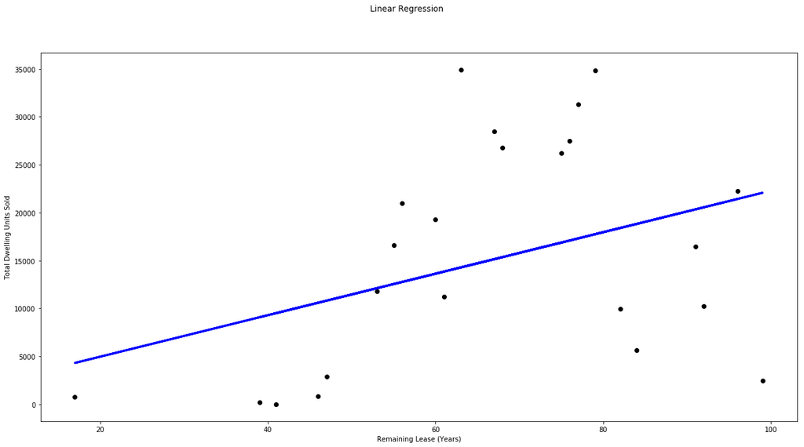

```python
y_pred = dwellings_lr.predict(X_test)

fig= plt.figure(figsize=(20,10))

plt.scatter(X_test, y_test,  color='black')

plt.plot(X_test, y_pred, color='blue', linewidth=3)

fig.suptitle('Linear Regression')
plt.xlabel('Remaining Lease (Years)')
plt.ylabel('Total Dwelling Units Sold')

plt.show()
```

```python
print(dwellings_lr.coef_)
print(dwellings_lr.intercept_)
```

```
[[216.42842378]]
[642.90773916]
```

Creating Linear Equation of Model

### Linear Equation of Model:

#### Total Dwelling Units Sold = 642.90773916 + 216.428423783

##### With every increase in year of remaining lease, the total number of dwelling units sold would increase by 216.42842378

Predicting the total number of dwelling units sold

```python
def predict_ttl_dwellings_sold(remaining_lease):
    return dwellings_lr.predict(remaining_lease)
```

```python
remaining_lease = 60 #Change accordingly to the remaining lease that you want to ues to predict the total number of dwelling units sold

predict_ttl_dwellings_sold([[remaining_lease]])
```

```
array([[13628.61316595]])
```

# Insights/Evaluation

Based on the analysis that was done above, we have derived certain trends and observations based on the key focus areas that were being identified initally.

Though most of the Residential Areas in Singapore are built to completion in the year 1984, the popularity of the type of dwelling units sold in these residential areas based on the building completion year differ rather significantly from one another.

Most of the dwelling units sold are located in the West awnd North-East Region, with Jurong West (West Region) boasting the largest number of dwelling units sold (in total).

# Future Work

My reseach currently **only covers public housing units up to Executive Flats**. In future, this research can be **extended to cover private housing units**.

**Prices of Residential Units** can be a factor that can be included for analysis in future.

Currently, the geospatial analysis in my research covers **only the building area clusters** instead of **the indivual residential areas** due to the **limiations of *GEOPY's API (Maximum of 2500 Requests)***, rendering it **impossible to obtain the exact longtitude and latitude** for each and every of the residential areas in Singapore.

More advanced geospatial analysis techniques can be applied in the future to provide a more **comprehensive and extensive analysis of these residential areas of Singapore.**

```python
!jupyter nbconvert --to html Tan_Wei_Xuan_Final_Project.ipynb
```

```
[NbConvertApp] Converting notebook Tan_Wei_Xuan_Final_Project.ipynb to html
[NbConvertApp] Writing 607504 bytes to Tan_Wei_Xuan_Final_Project.html
```